# 459_hiv

WeiDai

April 9, 2019

# Preliminaries

```r
library(readxl)
library(haven)
library(gghighlight)
library(corrr);library(nlme);library(lme4)
library(geepack)
library(tidyverse)
```

```r
hivfu_raw <- read_excel("data/Project2 HIVFU.xls") %>% as.data.frame()
il2 <- read_sas("data/il2.sas7bdat", NULL)
```

Research Question

- Does IL-2(grp A) has an significant effect on HIV viral load(“rtpcrnih”) than control group(grp B) from 14 months post-randomization onwards?
- In this case, less viral load means better outcome. I recode HIV viral load(“rtpcrnih”) to “1” as below detectable virus threshold and “0” as above. This aims to study the odds of having good outcomes between 2 treatment groups from 14 months post-randomization onwards.

# Exploratory data analysis

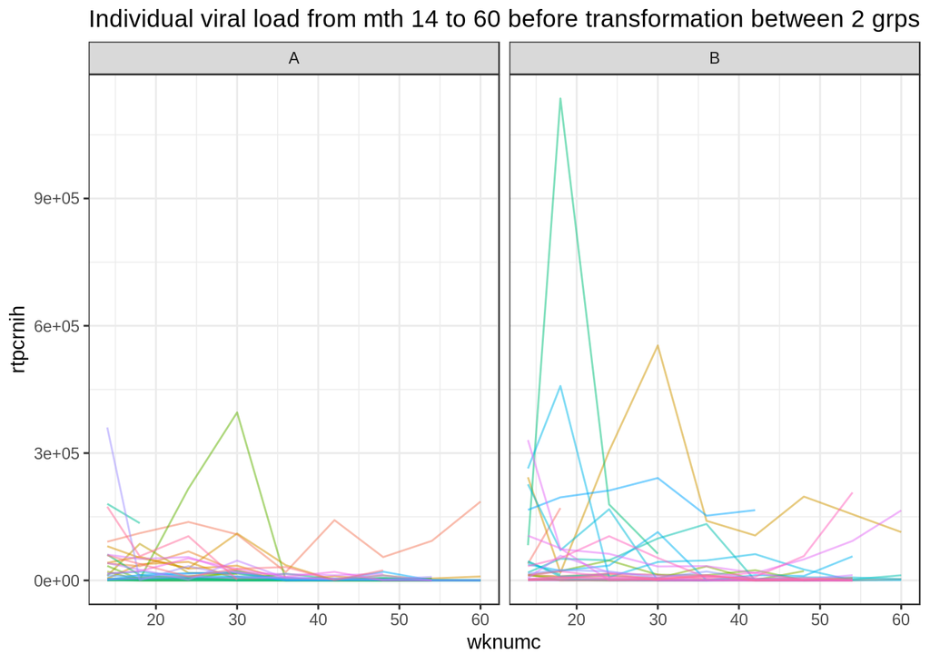

```r
ggplot(data = hivfu_raw, aes(x = wknumc, y = rtpcrnih, group = id)) +
  geom_line(aes(col = id), alpha = 0.5, show.legend = F ) +
  #scale_y_continuous(limits = c(0, 120000)) +
  theme_bw() +
  facet_wrap( ~ grp) +
  labs(title = "Individual viral load from mth 14 to 60 before transformation between 2 grps")
```

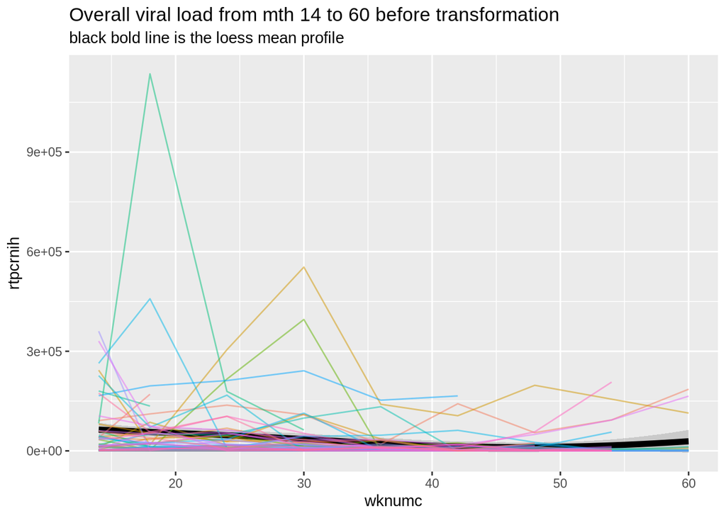

```r
ggplot(data = hivfu_raw, aes(x = wknumc, y = rtpcrnih)) +
  geom_smooth(size = 2, col = "black", method = "loess") +
  geom_line(aes(col = id),alpha = 0.5, show.legend = F ) +
  labs(title = "Overall viral load from mth 14 to 60 before transformation",
       subtitle = "black bold line is the loess mean profile")
```

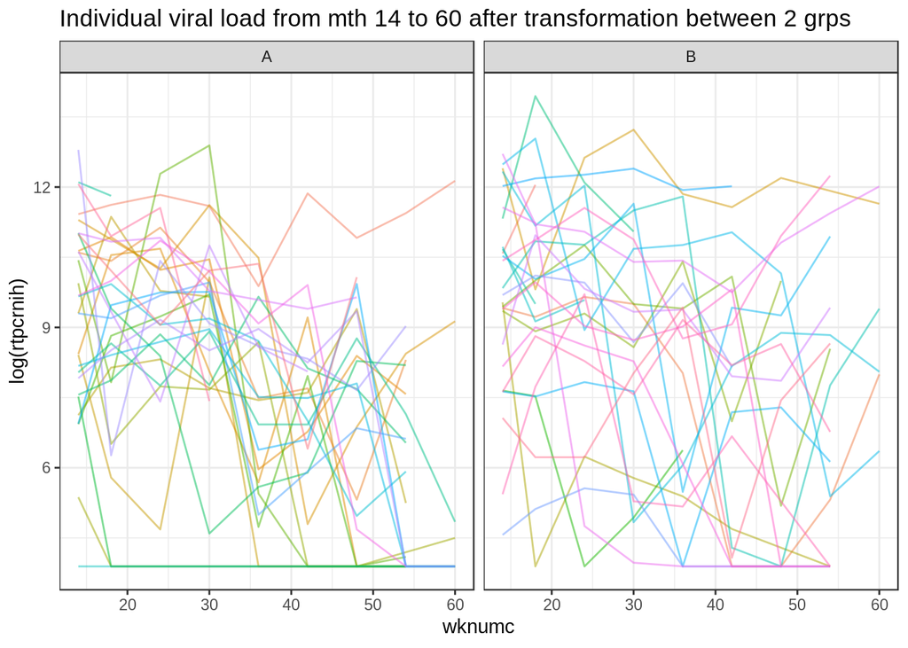

```r
ggplot(data = hivfu_raw, aes(x = wknumc, y = log(rtpcrnih), group = id)) +
  geom_line(aes(col = id), alpha = 0.5, show.legend = F ) +
  #scale_y_continuous(limits = c(0, 120000)) +
  theme_bw() +
  facet_wrap( ~ grp) +
  labs(title = "Individual viral load from mth 14 to 60 after transformation between 2 grps")
```

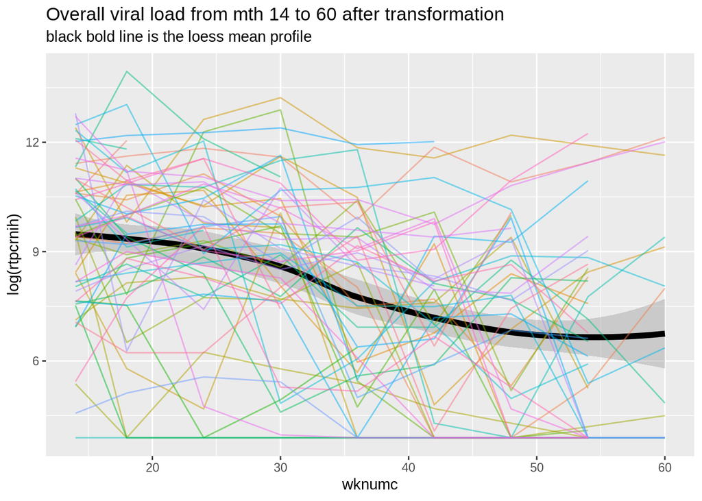

```r
ggplot(data = hivfu_raw, aes(x = wknumc, y = log(rtpcrnih))) +
  geom_smooth(size = 2, col = "black", method = "loess") +
  geom_line(aes(col = id),alpha = 0.5, show.legend = F ) +
  labs(title = "Overall viral load from mth 14 to 60 after transformation",
       subtitle = "black bold line is the loess mean profile")
```

## Construct a groupedData Object(spread and gather)

resp ~ cov | group

```r
hiv_grouped <- groupedData(formula = rtpcrnih ~ wknumc | id, data = hivfu_raw[,-c(3, 5)], order.groups = F)
```

```r
hiv_spread <- hiv_grouped %>%
  mutate(wknumc = paste0(wknumc)) %>%
  spread(wknumc, rtpcrnih)
```

```r
hiv_gather <- hiv_spread %>%
  gather(`14`, `18`, `24`, `30`, `36`, `42`, `48`, `54`, `60`, key = wknumc, value =  rtpcrnih) %>%
  mutate(wknumc = as.numeric(wknumc)) %>%
  arrange(grp, id)
```

## visualization

```r
hiv_spread %>%
  count(grp)
```

```
## # A tibble: 2 x 2
##   grp       n
##   <chr> <int>
## 1 A        29
## 2 B        29
```

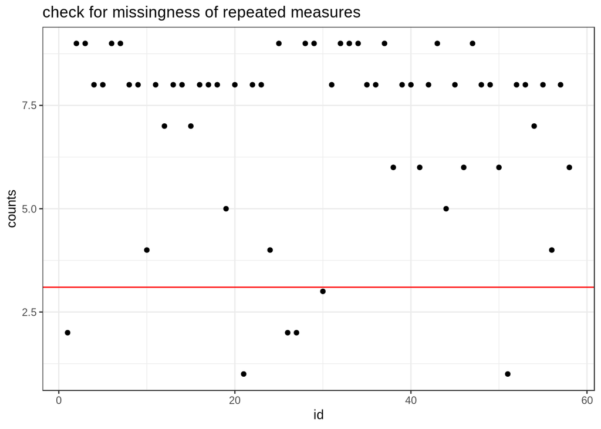

```r
a <- hivfu_raw %>% count(id)
ggplot(data = a, aes(x = 1:58, y = n)) +
  geom_point() +
  labs(title = "check for missingness of repeated measures",
       x = "id",
       y = "counts") +
  theme_bw() +
  geom_hline(yintercept = 3.1, col = "red")
```

The plot shows the missingness of each individual. Each id should have 9 complete viral load measurements. Here, I set the threadhold as n = 3. For individual has 3 or less recorded measurements will be excluded from the analysis.

```r
hiv_spread %>% filter(is.na(`30`)) %>% group_by(id)
```

```
## # A tibble: 6 x 11
## # Groups:   id [6]
##   grp   id           `14`   `18`  `24`  `30`  `36`  `42`  `48`  `54`  `60`
##   <chr> <fct>       <dbl>  <dbl> <dbl> <dbl> <dbl> <dbl> <dbl> <dbl> <dbl>
## 1 A     26-56-01-2 180371 134910    NA    NA    NA    NA    NA    NA    NA
## 2 B     19-24-17-5  39341 170498    NA    NA    NA    NA    NA    NA    NA
## 3 B     26-09-94-0 541222     NA    NA    NA    NA    NA    NA    NA    NA
## 4 B     26-56-12-7  43196  13393    NA    NA    NA    NA    NA    NA    NA
## 5 B     26-58-23-9  45338   9213 14549    NA    NA    NA    NA    NA    NA
## 6 B     26-97-07-5  60248     NA    NA    NA    NA    NA    NA    NA    NA
```

Here, we can see that the individuals excluded from analysis are severe cases. I think here we have sufficient reasons to assume that these individal have died or dropped out. There is no reason to impute these large numbers.

The drawback is that group B has 5 excluded and A has 1. That might cause problems in the following analysis.

group by time points

```r
hivfu_raw %>% group_by(wknumc) %>%
  summarise(min = min(rtpcrnih),
            median = median(rtpcrnih),
            mean = mean(rtpcrnih),
            max = max(rtpcrnih),
            missing = 58 - n())
```

```
## # A tibble: 9 x 6
##   wknumc   min median   mean     max missing
##    <dbl> <dbl>  <dbl>  <dbl>   <dbl>   <dbl>
## 1     14    49 16082. 63038.  541222       0
## 2     18    49 13216  60049. 1135625       4
## 3     24    49 14549  40912.  304743       5
## 4     30    49  9309  42323.  553557       6
## 5     36    49  3051  16524.  152592      11
## 6     42    49  1556  13410.  165500      10
## 7     48    49  1705  12645.  197500      15
## 8     54    49   372  13100.  207156      19
## 9     60    49   577  32857.  185743      43
```

Here, the untransformed mean is much larger than median. We can tell that the distribution of viral load is right skewed.

```r
hivfu_raw %>% group_by(wknumc) %>%
  summarise(min = min(log(rtpcrnih)),
            median = median(log(rtpcrnih)),
            mean = mean(log(rtpcrnih)),
            max = max(log(rtpcrnih)),
            missing = 58 - n())
```

```
## # A tibble: 9 x 6
##   wknumc   min median  mean   max missing
##    <dbl> <dbl>  <dbl> <dbl> <dbl>   <dbl>
## 1     14  3.89   9.69  9.56  13.2       0
## 2     18  3.89   9.49  9.18  13.9       4
## 3     24  3.89   9.59  9.06  12.6       5
## 4     30  3.89   9.14  8.73  13.2       6
## 5     36  3.89   8.02  7.60  11.9      11
## 6     42  3.89   7.34  7.13  12.0      10
## 7     48  3.89   7.44  6.97  12.2      15
## 8     54  3.89   5.92  6.37  12.2      19
## 9     60  3.89   6.36  7.04  12.1      43
```

The mean and median after log transformation are much closer to each other than untransformed. This indicates that a log transformation is a better option.

## mean plots

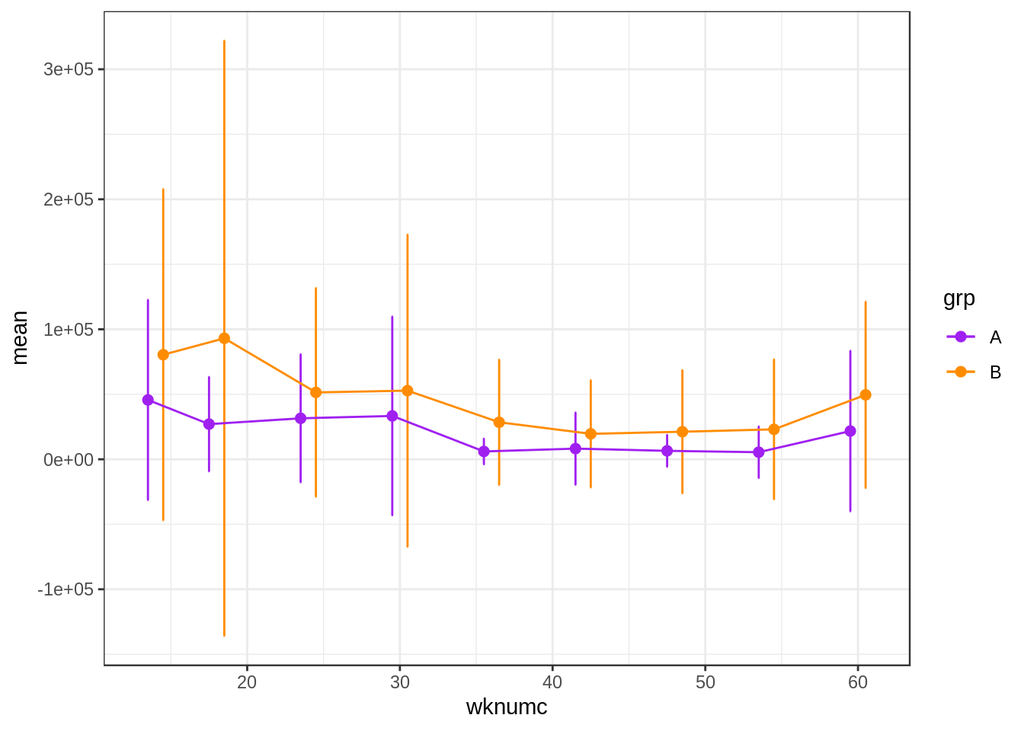

```r
mean_untrans <- hivfu_raw %>%
  group_by(grp, wknumc) %>%
  summarise(mean = mean(rtpcrnih), sd = sd(rtpcrnih))

mean_log <-  hivfu_raw %>%
  group_by(grp, wknumc) %>%
  summarise(mean = mean(log(rtpcrnih)), sd = sd(log(rtpcrnih)))

pd <- position_dodge(2) # move them 2 to the left and right

ggplot(mean_untrans, aes(x = wknumc, y = mean, col = grp)) +
    geom_errorbar(aes(ymin = mean - sd,
                      ymax = mean + sd),
                  width = 0.2, position = pd) +
    geom_point(size = 2, position = pd) +
    geom_line(aes(group = grp), position = pd) +
    scale_color_manual(values = c("purple", "darkorange")) +
    theme_bw() +
    labs("mean profile of viral load before log transformation")
```

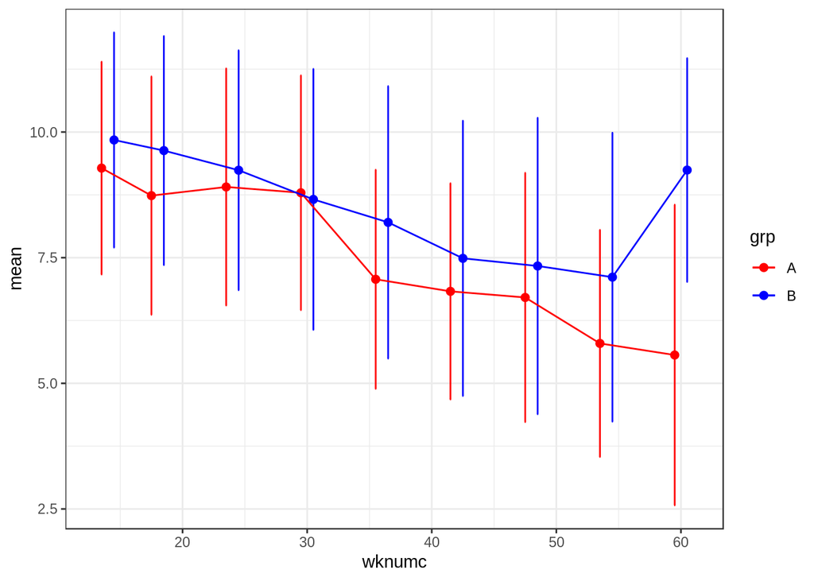

```r
ggplot(mean_log, aes(x = wknumc, y = mean, col = grp)) +
    geom_errorbar(aes(ymin = mean - sd,
                      ymax = mean + sd),
                  width = 0.2, position = pd) +
    geom_point(size = 2, position = pd) +
    geom_line(aes(group = grp), position = pd) +
    scale_color_manual(values = c("red", "blue")) +
    theme_bw()  +
    labs("mean profile of viral load after log transformation")
```

## imputation

```r
hiv_spread2 <- hiv_spread %>% filter(!is.na(`30`))
# filter out cases with very few measurements
```

a look at the missing value

```r
hiv_spread2[,-c(1:2)] %>% filter(!complete.cases(.)) %>%
  tail(10)
```

```
##        14    18     24    30    36    42    48     54 60
## 30     96   167    260   227    49    49    49     49 NA
## 31  16177 24535  21100  5909 20829  3463    NA     NA NA
## 32   5613 58079  18523 11306 11850  2851  2588  12344 NA
## 33 105304 75515    116    53    49    49    49     49 NA
## 34   3511  8122   5505  3927    NA    49    49     NA NA
## 35  12024 21258   8348  6191  8255 18247    49     49 NA
## 36  33701 52499 104208 53040  6395  8640 57256 207156 NA
## 37    229  2275  16457   197   176   790    NA     49 NA
## 38   2039  6720   3944  1937  9510  3611  5677    869 NA
## 39   1169   505    505  3046 12412    59  1705   5749 NA
```

Strategy for imputation

- Delete patient with 3 or less repeated measurements(6 patients)
- I assume the NAs after 49 are still 49. (patients don’t show up once their conditions get better)
- Log transform the viral load.
- Multiple impulation to the missing values.

```r
temp_gather <- temp_spread %>%
  gather(`14`, `18`, `24`, `30`, `36`, `42`, `48`, `54`, `60`, key = wknumc, value =  rtpcrnih) %>%
  mutate(wknumc = as.numeric(wknumc)) %>%
  arrange(grp, id) %>%
  mutate(lvload = round(log(rtpcrnih),2)) # log transform


imp_info <- mice::mice(temp_gather[,-4], m=5, maxit = 50, method = 'pmm', seed = 500)
imp_gather <- mice::complete(imp_info, 1) # change number to check imputation
#write.csv(imp_gather, "data/hiv_imputed.csv")
```

# repeated measures ANOVA

mean plot

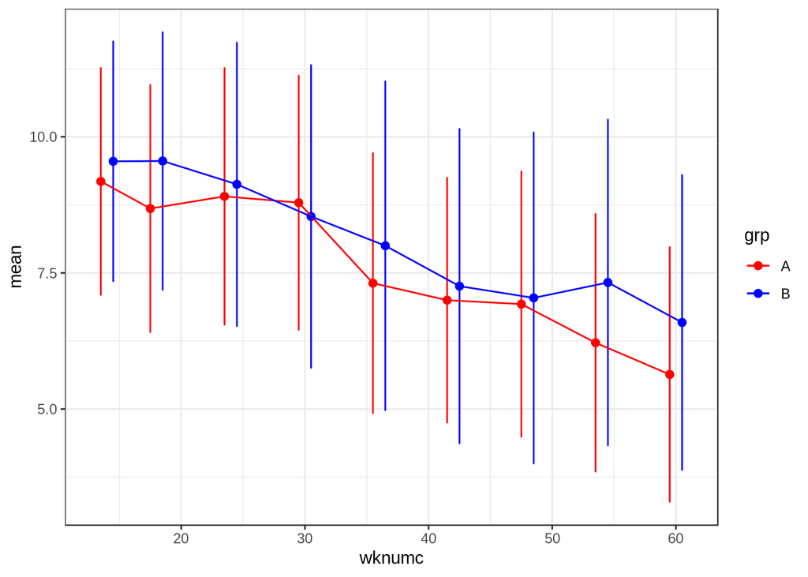

```r
mean_imp <- imp_gather %>%
  group_by(grp, wknumc) %>%
  summarise(mean = mean(lvload), sd = sd(lvload))

ggplot(mean_imp, aes(x = wknumc, y = mean, col = grp)) +
    geom_errorbar(aes(ymin = mean - sd,
                     ymax = mean + sd),
                width = 0.2, position = position_dodge(2)) +
    geom_point(size = 2, position = pd) +
    geom_line(aes(group = grp), position = pd) +
    scale_color_manual(values = c("red", "blue")) +
    theme_bw() +
    labs("mean profiles for each group after imputation")
```

```r
imp_spread <- imp_gather %>%
  mutate(wknumc = paste0(wknumc)) %>%
  spread(wknumc, lvload)


hiv_cor <- hiv_spread %>%
  select(`14`:`60`) %>%
  correlate(use = "pairwise.complete.obs", diagonal = 1, quiet = T) %>%
  #rearrange() %>%  # rearrange the correlation in order
  shave(upper = F)  # delete half of the redundant values

hiv_cor %>% fashion() # same as round()
```

```
##   rowname  X14  X18  X24  X30  X36  X42  X48  X54  X60
## 1      14 1.00  .25  .48  .32  .39  .42  .45  .22  .55
## 2      18      1.00  .34  .08  .38  .52  .14  .13  .06
## 3      24           1.00  .81  .58  .66  .71  .40  .57
## 4      30                1.00  .63  .56  .72  .16  .45
## 5      36                     1.00  .65  .65  .06  .31
## 6      42                          1.00  .70  .36  .74
## 7      48                               1.00  .85  .62
## 8      54                                    1.00 1.00
## 9      60                                         1.00
```

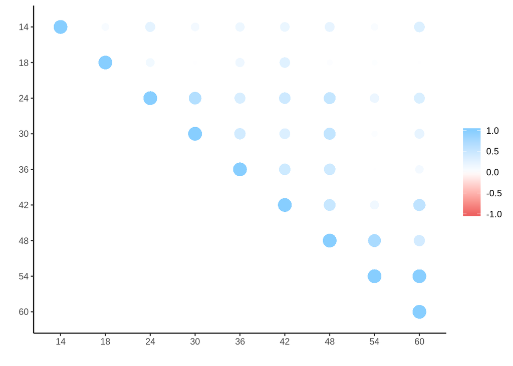

```r
rplot(hiv_cor) # make fancy plots
```

```r
rmaov <- lme(lvload ~ grp + factor(wknumc) + grp * factor(wknumc), data = imp_gather, random = ~1 | id, correlation = corCompSymm(form = ~wknumc | id))
```

```r
car::Anova(rmaov)
```

```
## Analysis of Deviance Table (Type II tests)
##
## Response: lvload
##                       Chisq Df Pr(>Chisq)
## grp                  0.7453  1     0.3880
## factor(wknumc)     226.7319  8     <2e-16 ***
## grp:factor(wknumc)   7.8943  8     0.4439
## ---
## Signif. codes:  0 '***' 0.001 '**' 0.01 '*' 0.05 '.' 0.1 ' ' 1
```

```r
anova.lme(rmaov)
```

```
##                    numDF denDF  F-value p-value
## (Intercept)            1   400 798.6509  <.0001
## grp                    1    50   0.7453  0.3921
## factor(wknumc)         8   400  28.3415  <.0001
## grp:factor(wknumc)     8   400   0.9868  0.4457
```

Here, the time factor(wknumc) is very significant according to repeated measures ANOVA. While grp and grp time interaction are not significant(p value = 0.39 and 0.44). This verifies what we saw in the visualization.

# linear mixed effect model

## int only

lmer(formular = outcome ~ fixed effect + (random effect | id))

```r
imp_gather <- imp_gather %>%
  mutate(time = wknumc - 14)
```

Here, I recode `wknumc` - 14 as `time` so that month 14 can be the baseline and can be better interpreted through the intercept.

```r
lme_ict <- lmer(formula = lvload ~ 1 + time + grp + (1 |id), data = imp_gather, REML = T)
```

```r
summary(lme_ict)
```

```
## Linear mixed model fit by REML ['lmerMod']
## Formula: lvload ~ 1 + time + grp + (1 | id)
##    Data: imp_gather
##
## REML criterion at convergence: 1926.6
##
## Scaled residuals:
##     Min      1Q  Median      3Q     Max
## -2.7527 -0.6692  0.0463  0.6256  3.2147
##
## Random effects:
##  Groups   Name        Variance Std.Dev.
##  id       (Intercept) 3.717    1.928
##  Residual             2.655    1.629
## Number of obs: 468, groups:  id, 52
##
## Fixed effects:
##              Estimate Std. Error t value
## (Intercept)  9.258435   0.394314  23.480
## time        -0.073376   0.004969 -14.766
## grpB         0.481032   0.557189   0.863
##
## Correlation of Fixed Effects:
##      (Intr) time
## time -0.280
## grpB -0.652  0.000
```

```r
hiv_pred <- imp_gather %>%
  mutate(.pred_int = predict(lme_ict)) %>%
  mutate(resid_int  = residuals(lme_ict))
```

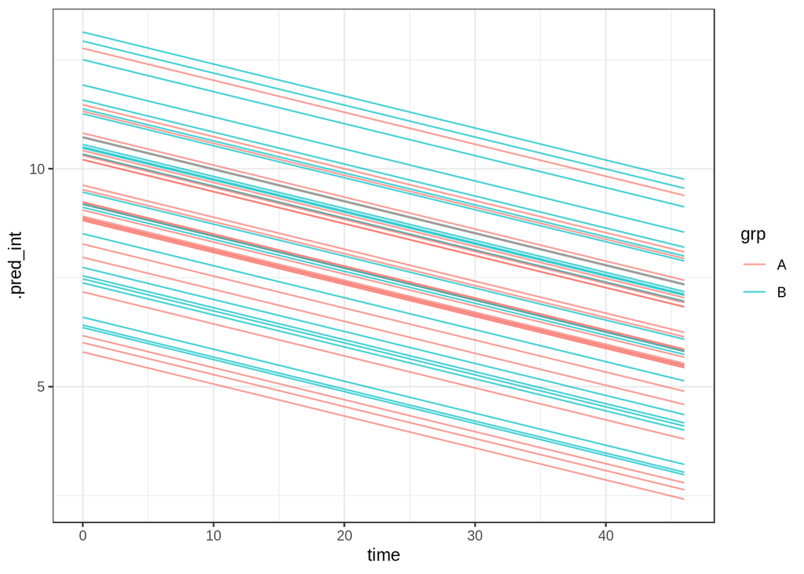

```r
ggplot(data = hiv_pred, aes(x = time, y = .pred_int, col = grp)) +
  geom_line(aes(group = id), alpha = 0.7) +
  theme_bw()
```

## int and time effect

```r
lme_time <- lmer(formula = lvload ~ 1 + time * grp + (time ||id), data = imp_gather, REML = T)
```

```r
summary(lme_time)
```

```
## Linear mixed model fit by REML ['lmerMod']
## Formula: lvload ~ 1 + time * grp + ((1 | id) + (0 + time | id))
##    Data: imp_gather
##
## REML criterion at convergence: 1924.7
##
## Scaled residuals:
##     Min      1Q  Median      3Q     Max
## -2.8430 -0.6186  0.0529  0.5879  3.2077
##
## Random effects:
##  Groups   Name        Variance  Std.Dev.
##  id       (Intercept) 3.4020678 1.84447
##  id.1     time        0.0007865 0.02804
##  Residual             2.4548644 1.56680
## Number of obs: 468, groups:  id, 52
##
## Fixed effects:
##              Estimate Std. Error t value
## (Intercept)  9.356991   0.390108  23.986
## time        -0.077811   0.008396  -9.268
## grpB         0.267495   0.574224   0.466
## time:grpB    0.009609   0.012359   0.778
##
## Correlation of Fixed Effects:
##           (Intr) time   grpB
## time      -0.288
## grpB      -0.679  0.195
## time:grpB  0.195 -0.679 -0.288
```

```r
hiv_pred <- imp_gather %>%
  mutate(.pred_3 = predict(lme_time))%>%
  mutate(resid_3  = residuals(lme_time))
```

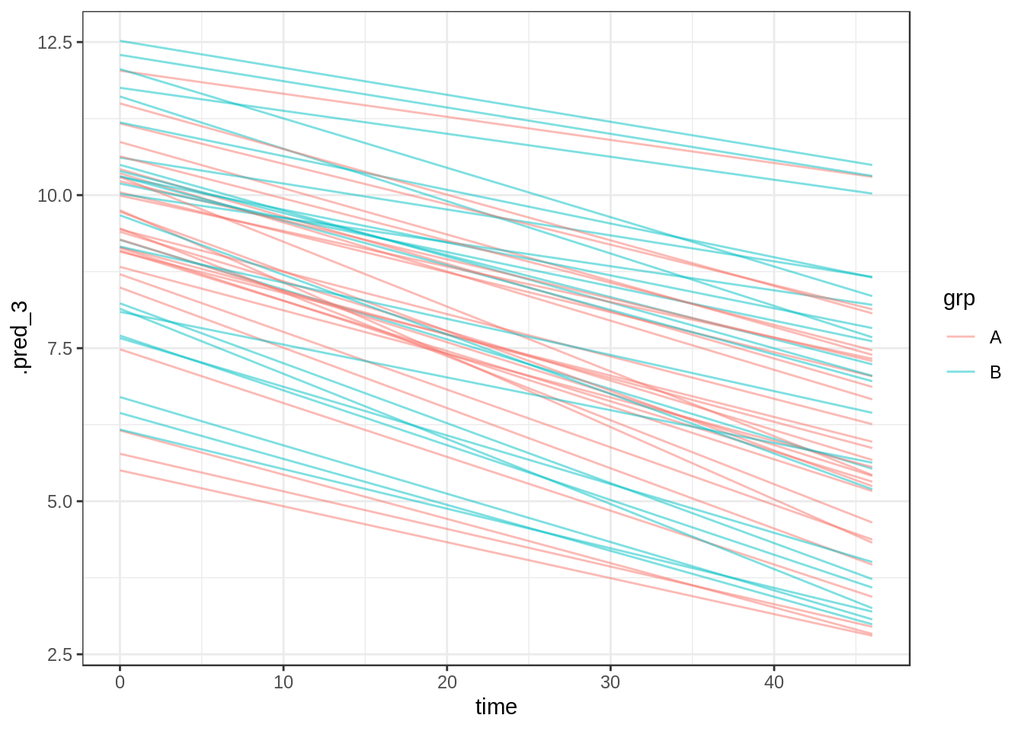

```r
ggplot(data = hiv_pred, aes(x = time, y = .pred_3)) +
  geom_line(aes(group = id, col = grp), alpha = 0.5) +
  theme_bw()
```

```r
anova(lme_ict, lme_time)
```

```
## refitting model(s) with ML (instead of REML)
```

```
## Data: imp_gather
## Models:
## lme_ict: lvload ~ 1 + time + grp + (1 | id)
## lme_time: lvload ~ 1 + time * grp + ((1 | id) + (0 + time | id))
##          Df    AIC    BIC  logLik deviance  Chisq Chi Df Pr(>Chisq)
## lme_ict   5 1927.8 1948.5 -958.89   1917.8
## lme_time  7 1923.2 1952.3 -954.61   1909.2 8.5544      2    0.01388 *
## ---
## Signif. codes:  0 '***' 0.001 '**' 0.01 '*' 0.05 '.' 0.1 ' ' 1
```

```r
MuMIn::r.squaredGLMM(lme_ict)
```

```
##            R2m       R2c
## [1,] 0.1691376 0.6538199
```

```r
MuMIn::r.squaredGLMM(lme_time)
```

```
##            R2m       R2c
## [1,] 0.1685245 0.6823585
```

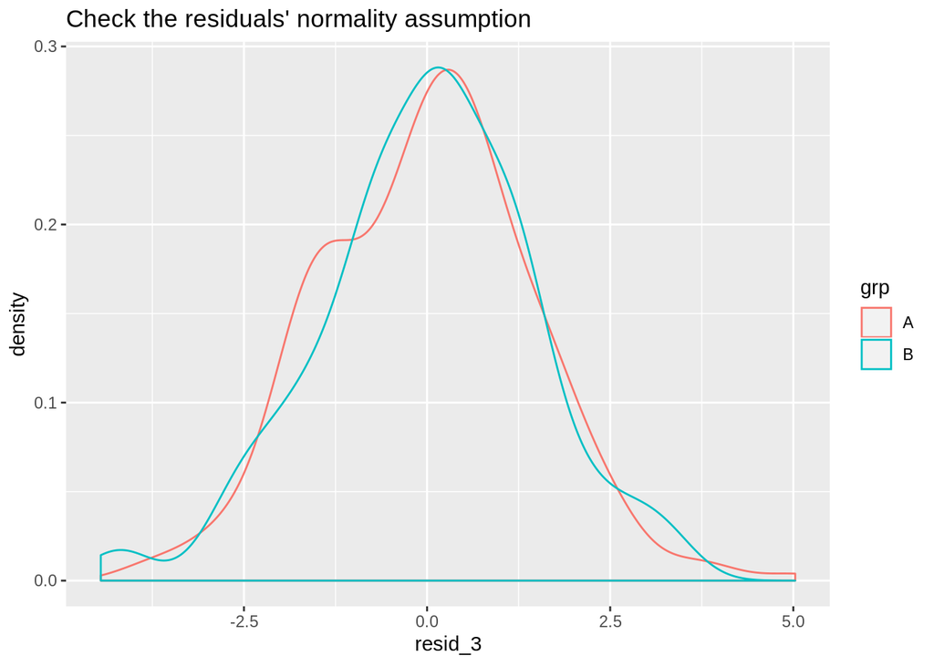

```r
ggplot(data = hiv_pred, aes(x = resid_3)) +
  geom_density(aes(col = grp)) +
  labs(title = "Check the residuals' normality assumption")
```

```r
imp_gather <- imp_gather %>%
  mutate(vcat = ifelse(lvload <= 3.90, 1, 0))

imp_gather %>%
  group_by(grp) %>%
  count(vcat)
```

```
## # A tibble: 4 x 3
## # Groups:   grp [2]
##   grp    vcat     n
##   <chr> <dbl> <int>
## 1 A         0   197
## 2 A         1    55
## 3 B         0   171
## 4 B         1    45
```

```r
imp_gather %>%
  group_by(time) %>%
  summarise(prop = mean(vcat))
```

```
## # A tibble: 9 x 2
##    time   prop
##   <dbl>  <dbl>
## 1     0 0.0192
## 2     4 0.0769
## 3    10 0.0962
## 4    16 0.0962
## 5    22 0.192
## 6    28 0.25
## 7    34 0.346
## 8    40 0.385
## 9    46 0.462
```

## GLMM

```r
#e <- glmer(vcat ~  time * grp + ( | id), data = imp_gather, family = "binomial")
```

I tried to use GLMM, but the model failed to converge and has very large eigenvalue.

## GEE

```r
gee_ind <- geeglm(vcat ~  1 + time *grp, data = imp_gather, id = id, family = "binomial", scale.fix = T)

gee_ex <- geeglm(vcat ~  1 + time *grp, data = imp_gather, id = id, family = "binomial", scale.fix = T, corstr = "exchangeable")

gee_ar1 <- geeglm(vcat ~  1 + time *grp, data = imp_gather, id = id, family = "binomial", scale.fix = T, corstr = "ar1")

gee_unstr <- geeglm(vcat ~  1 + time *grp, data = imp_gather, id = id, family = "binomial", scale.fix = T, corstr = "unstr")
```

```r
list(gee_ind, gee_ex, gee_ar1, gee_unstr) %>%
  map(MuMIn::QIC)
```

```
## [[1]]
##      QIC
## 450.8981
##
## [[2]]
##      QIC
## 454.8306
##
## [[3]]
##      QIC
## 450.4746
##
## [[4]]
##          QIC
## 7.443201e+31
```

```r
summary(gee_ar1)
```

```
##
## Call:
## geeglm(formula = vcat ~ 1 + time * grp, family = "binomial",
##     data = imp_gather, id = id, corstr = "ar1", scale.fix = T)
##
##  Coefficients:
##             Estimate  Std.err   Wald Pr(>|W|)
## (Intercept) -3.27347  0.88924 13.551 0.000232 ***
## time         0.07284  0.02148 11.500 0.000696 ***
## grpB         0.46033  0.98804  0.217 0.641286
## time:grpB   -0.02010  0.02366  0.722 0.395455
## ---
## Signif. codes:  0 '***' 0.001 '**' 0.01 '*' 0.05 '.' 0.1 ' ' 1
##
## Scale is fixed.
##
## Correlation: Structure = ar1  Link = identity
##
## Estimated Correlation Parameters:
##       Estimate Std.err
## alpha   0.8173 0.04407
## Number of clusters:   52   Maximum cluster size: 9
```

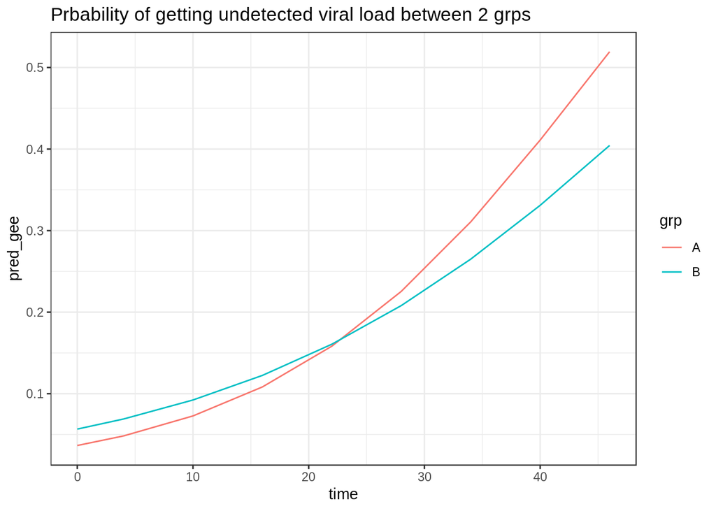

```r
gee_pred <- imp_gather %>%
  mutate(pred_gee = predict(gee_ar1, type = "response"))

gee_pred %>% ggplot() +
  geom_line(aes(x = time, y = pred_gee, col = grp)) +
  theme_bw() +
  labs(title = "Prbability of getting undetected viral load between 2 grps")
```

# Summary

Research Question

- Does IL-2(grp A) has an significant effect on HIV viral load(“rtpcrnih”) than control group(grp B) from 14 months post-randomization onwards?

We use repeated measures ANOVA, linear mixed effect model and GEE to find out if there is a difference in effect between 2 treatment groups.

All evidence suggests that there is not a significant effect between treatments.

The treatment effect is slightly better for grp A. IL-2(Grp A) does not have an significant effect in reducing HIV viral load from mth 14 to 60 than group B.